# Week 3

## Preliminaries

## activity-3.Rmd

- Create `activity-3.Rmd` in your in-class directory
- Use `output: github_document`
- Insert in R chunk to load `tidyverse` and `babynames`

## FYI: caching

The output of r chunks can be cached (saved) so that they don't need to be re-run everytime you re-knit.

````r
#```{r compute-stuff, cache = TRUE}
# my crazy intensive computing step
#```
````

- You may want to add cached files to your .gitignore.
- Labeling chunks can help with debugging
- Many more chunk options are available (search: knitr chunk options)

## Data Wrangling

## Two paradigms

### R

```r
cyl4s <- mtcars[mtcars$cyl == 4, ]
mean(cyl4s$mpg)
```

```
## [1] 26.66364
```

### R with dplyr

```r
library(dplyr)
cyl4s <- filter(mtcars, cyl == 4)
summarize(cyl4s, mean = mean(mpg))
```

```
##       mean
## 1 26.66364
```

## R Subsetting

```r
cyl4s <- mtcars[mtcars$cyl == 4, ]
```

- Square brackets are used to subset dataframes.
- `[rows, columns]`

## R Summaries

```r
mean(cyl4s$mpg)
```

```
## [1] 26.66364
```

- Many commands operate on a *vector* (column) of data extracted from a dataframe using the `$`.

## dplyr Subsetting

```r
cyl4s <- filter(mtcars, cyl == 4)
```

- `dplyr` contains separate functions to *filter* the rows and *select* the columns.
- The dataframe is one argument and the column names are another (no `$`).

```r
cyl4s <- mtcars %>% filter(cyl == 4)
```

- Can also *chain* commands using the pipe.

## dplyr Summaries

```r
summarize(cyl4s, mean = mean(mpg))
```

```
##       mean
## 1 26.66364
```

- Any numerical summary that you want to apply to a column of a dataframe is specified within `summarize()`.

```r
cyl4s %>% summarize(mean = mean(mpg))
```

```
##       mean
## 1 26.66364
```

- This, too, can be put into a chain.

## Two paradigms

### R

```r
cyl4s <- mtcars[mtcars$cyl == 4, ]
mean(cyl4s$mpg)
```

```
## [1] 26.66364
```

### R with dplyr

```r
library(dplyr)
cyl4s <- filter(mtcars, cyl == 4)
summarize(cyl4s, mean = mean(mpg))
```

```
##       mean
## 1 26.66364
```

## Why dplyr?

Data sets are often of high *volume* (lots of rows) and high *variety* (lots of columns). This is overwhelming to visualize and analyze, so we find ourselves chopping the data set up into more manageable and meaningful chunks. We also often need to perform operations to organize and clean our data.

This is all possible in base R, but with `dplyr`, it is **simple**, **readible**, and **fast**.

[figure not shown]

## The Five Verbs

- `select()`
- `filter()`
- `mutate()`
- `arrange()`
- `summarize()`

## Philosophy

- Each verb takes a data frame and returns a data frame
  - actually a `tbl_df`
  - allows chaining with `%>%`
- Idea:
  - master a few simple commands
  - use your creativity to combine them
- Cheat sheet:
  - https://rstudio.com/resources/cheatsheets

## `select()`

Subset the columns.

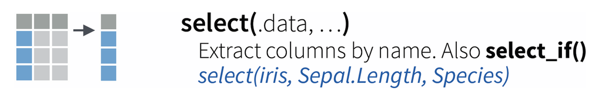

## `filter()`

Subset the rows.

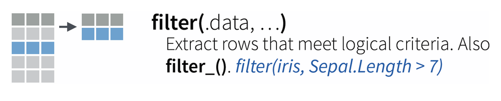

## `mutate()`

Add or modify a column.

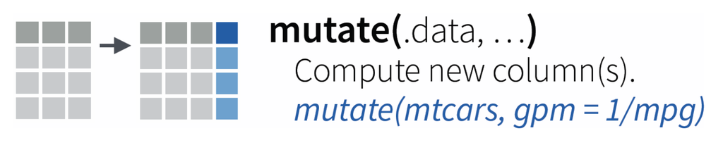

## `rename()`

Rename a column.

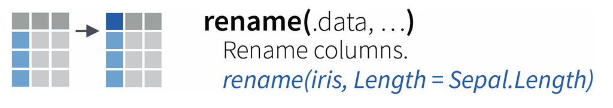

## `arrange()`

Sort the rows.

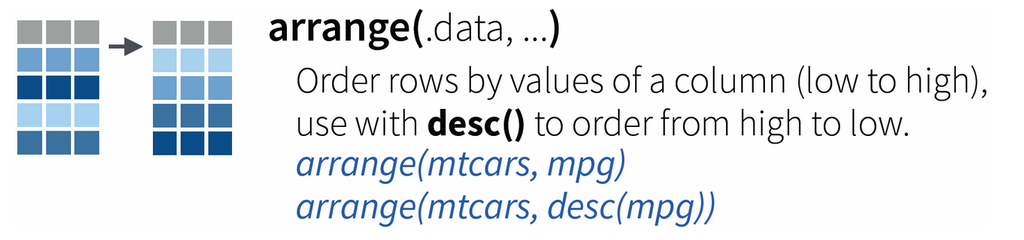

## `summarize()`

Summarize column(s) into a single row.

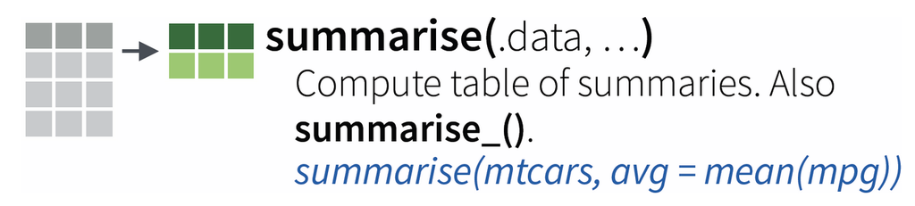

## Activity 3.1

- Add a new column to `babynames` that indicates whether or not the name proportion in that yearxgender was greater than 1%. Call that column `is_popular`.
- Which are the least popular "popular" names?

## Activity 3.1

- Add a new column to `babynames` that indicates whether or not the name proportion in that yearxgender was greater than 1%. Call that column `is_popular`.
- Which are the least popular "popular" names?

```r
babynames %>%
  mutate(is_popular = prop > .01) %>%
  filter(is_popular == TRUE) %>%
  arrange(prop)
```

```
## # A tibble: 3,875 x 6
##     year sex   name         n   prop is_popular
##    <dbl> <chr> <chr>    <int>  <dbl> <lgl>
##  1  1894 F     Grace     2361 0.0100 T
##  2  1969 F     Karen    17637 0.0100 T
##  3  1983 F     Crystal  17904 0.0100 T
##  4  2000 F     Madison  19967 0.0100 T
##  5  1960 M     Gary     21688 0.0100 T
##  6  1911 F     Florence  4424 0.0100 T
##  7  1967 M     Eric     17828 0.0100 T
##  8  1957 M     Larry    21913 0.0100 T
##  9  2003 M     Daniel   21032 0.0100 T
## 10  1934 M     Frank    10635 0.0100 T
## # ... with 3,865 more rows
```

## Activity 3.2

- Create a new object called `bella` that contains all instances of babies named "Bella" and all of the variables except `prop`.
- What `class()` is this object?
- Create a plot of the popularity of Bella over time.

## Activity 3.2

- Create a new object called `bella` that contains all instances of babies named "Bella" and all of the variables except `prop`.
- What `class()` is this object?
- Create a plot of the popularity of Bella over time.

```r
bella <- babynames %>%
  select(year, sex, name, n) %>%
  filter(name == "Bella")
```

or

```r
bella <- babynames %>%
  select(-prop) %>%
  filter(name == "Bella")
class(bella)
```

```
## [1] "tbl_df"     "tbl"        "data.frame"
```

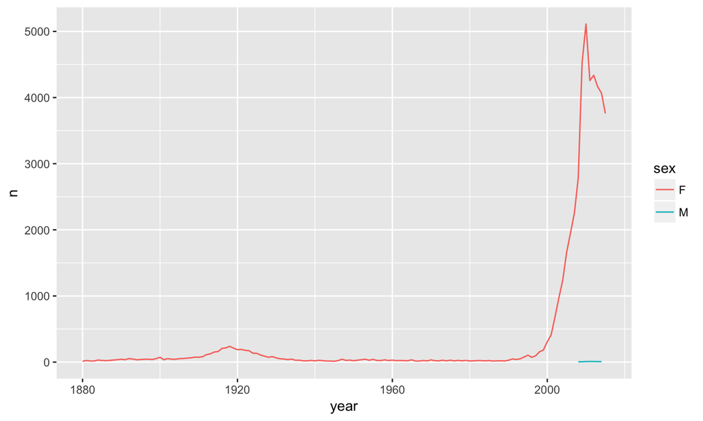

```r
babynames %>%
  select(year, sex, name, n) %>%
  filter(name == "Bella") %>%
  ggplot(aes(x = year, y = n)) +
  geom_line(aes(color = sex))
```

## Composition

[figure not shown]

[figure not shown]

- Pipe (`%>%`) is provided by the `magrittr` package
- Inspired by pipe (`|`) in UNIX

## Using the pipe

The expression

```r
mydata %>%
  verb(arg1)
```

is the same as:

```r
verb(mydata, arg1)
```

- It takes the output of the leading function and drops it in as the first argument of the trailing function.
- You can indicate the landing site with `.`

## Why the pipe?

Instead of having to read/write:

```r
select(filter(mutate(data, arg1), arg2), arg3)
```

You can do:

```r
data %>%
  mutate(arg1) %>%
  filter(arg2) %>%
  select(arg3)
```

## Coding Little Bunny Foo Foo

Nested form:

```r
bop(scoop(hop(foo_foo, through = forest), up = field_mice, on = head))
```

With pipes:

```r
foo_foo %>%
  hop(through = forest) %>%
  scoop(up = field_mice) %>%
  bop(on = head)
```

More on that analogy: - https://github.com/hadley/r4ds/blob/master/pipes.Rmd

## Practice

## Activity 3.3

- Without using `summarize()` or graphics, find the year in which your name was used most frequently.
- What was the most popular name that year?

## Activity 3.3

- Without using `summarize()` or graphics, find the year in which your name was used most frequently.
- What was the most popular name that year?

```r
babynames %>%
  filter(name == "Andrew") %>%
  arrange(desc(n))
```

```
## # A tibble: 245 x 5
##     year sex   name       n   prop
##    <dbl> <chr> <chr>  <int>  <dbl>
##  1  1987 M     Andrew 36199 0.0186
##  2  1988 M     Andrew 35727 0.0179
##  3  1989 M     Andrew 34809 0.0166
##  4  1986 M     Andrew 33853 0.0176
##  5  1990 M     Andrew 33653 0.0156
##  6  1991 M     Andrew 31525 0.0149
##  7  1992 M     Andrew 30534 0.0146
##  8  1985 M     Andrew 30160 0.0157
##  9  1993 M     Andrew 27314 0.0132
## 10  1994 M     Andrew 26006 0.0128
## # ... with 235 more rows
```

## Activity 3.3

- Without using `summarize()` or graphics, find the year in which your name was used most frequently.
- What was the most popular name that year?

```r
babynames %>%
  filter(year == 1987) %>%
  arrange(desc(n))
```

```
## # A tibble: 21,399 x 5
##     year sex   name            n   prop
##    <dbl> <chr> <chr>       <int>  <dbl>
##  1  1987 M     Michael     63638 0.0327
##  2  1987 F     Jessica     55990 0.0299
##  3  1987 F     Ashley      54845 0.0293
##  4  1987 M     Christopher 54476 0.0279
##  5  1987 M     Matthew     46473 0.0238
##  6  1987 F     Amanda      41786 0.0223
##  7  1987 M     Joshua      39991 0.0205
##  8  1987 M     David       36776 0.0189
##  9  1987 M     Andrew      36199 0.0186
## 10  1987 M     Daniel      35857 0.0184
## # ... with 21,389 more rows
```

## Aggregation

## `group_by()`

Indicate sub-groups of rows in a data set.

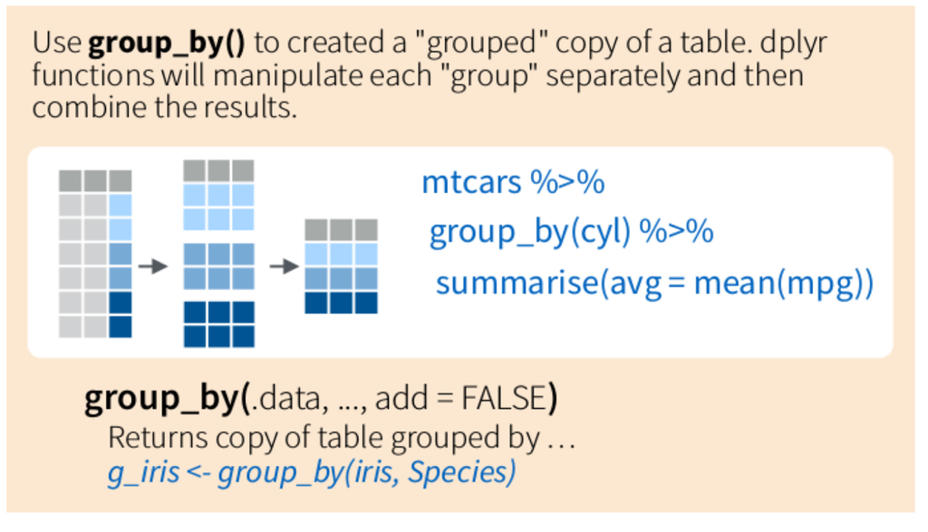

## `group_by()`

Indicate sub-groups of rows in a data set.

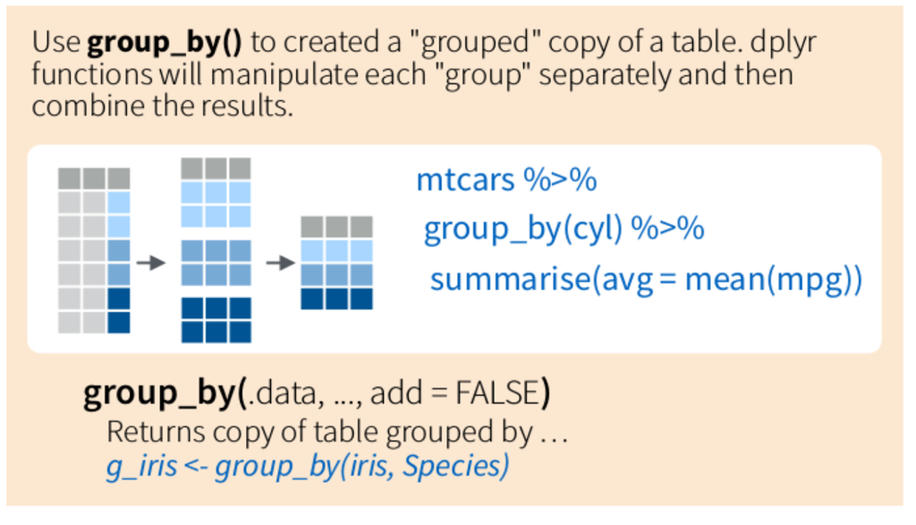

Total number of names in each year

```r
babynames %>%
  group_by(year) %>%
  summarize(count = n())
```

```
## # A tibble: 136 x 2
##     year count
##    <dbl> <int>
##  1  1880  2000
##  2  1881  1935
##  3  1882  2127
##  4  1883  2084
##  5  1884  2297
##  6  1885  2294
##  7  1886  2392
##  8  1887  2373
##  9  1888  2651
## 10  1889  2590
## # ... with 126 more rows
```

## Activity 3.4

- Which year had the greatest number of births?
- In a single pipeline, compute the earliest and latest year that each name appears.

## Activity 3.4

- Which year had the greatest number of births?
- In a single pipeline, compute the earliest and latest year that each name appears.

```r
babynames %>%
  group_by(year) %>%
  summarize(num_births = sum(n)) %>%
  arrange(desc(num_births))
```

```
## # A tibble: 136 x 2
##     year num_births
##    <dbl>      <int>
##  1  1957    4200146
##  2  1959    4156617
##  3  1960    4154877
##  4  1961    4140040
##  5  1958    4131784
##  6  1956    4121274
##  7  1962    4035565
##  8  1955    4012757
##  9  2007    3992280
## 10  1954    3979147
## # ... with 126 more rows
```

## Activity 3.4

- Which year had the greatest number of births?
- In a single pipeline, compute the earliest and latest year that each name appears.

```r
babynames %>%
  group_by(name) %>%
  summarize(earliest = min(year), latest = max(year))
```

```
## # A tibble: 95,025 x 3
##    name      earliest latest
##    <chr>        <dbl>  <dbl>
##  1 Aaban         2007   2015
##  2 Aabha         2011   2015
##  3 Aabid         2003   2003
##  4 Aabriella     2008   2015
##  5 Aada          2015   2015
##  6 Aadam         1987   2015
##  7 Aadan         2003   2015
##  8 Aadarsh       2000   2015
##  9 Aaden         2001   2015
## 10 Aadesh        2005   2011
## # ... with 95,015 more rows
```

## More . . .

Choose two of the following exercises to add to your activity and also please post a graphic to slack (the last bullet).

- **3.5**: Among popular names (let’s say at least 1% of the births in a given year), which name is the youngest—meaning that its first appearance as a popular name is the most recent?
- **3.6**: It seems like there is more diversity of names now than in the past. How have the number of names used changed over time? Has it been the same for boys and girls?
- **3.7**: Find the most popular names of the 1990s.
- **3.8**: Which names have been given to M and F most equally?
- Before class thursday, please create a visualization of this data set and post it (and it's code) to slack.